# Task 7: Developing a Graphic

TomHollinberger

9/20/2020

THIS RSCRIPT USES ROXYGEN CHARACTERS.  
YOU CAN PRESS ctrl+shift+K AND GO STRAIGHT TO A HTML.  
SKIPS THE HANDWORK OF CREATING A RMD, AFTER THE ORIGINAL WORK IS NONE IN A RSCRIPT.

# **Task 7 Developing a Graphic**

```r
flts <- nycflights13::flights
str(flts)
```

```
## tibble [336,776 x 19] (S3: tbl_df/tbl/data.frame)
##  $ year          : int [1:336776] 2013 2013 2013 2013 2013 2013 2013 2013 2013 2013 ...
##  $ month         : int [1:336776] 1 1 1 1 1 1 1 1 1 1 ...
##  $ day           : int [1:336776] 1 1 1 1 1 1 1 1 1 1 ...
##  $ dep_time      : int [1:336776] 517 533 542 544 554 554 555 557 557 558 ...
##  $ sched_dep_time: int [1:336776] 515 529 540 545 600 558 600 600 600 600 ...
##  $ dep_delay     : num [1:336776] 2 4 2 -1 -6 -4 -5 -3 -3 -2 ...
##  $ arr_time      : int [1:336776] 830 850 923 1004 812 740 913 709 838 753 ...
##  $ sched_arr_time: int [1:336776] 819 830 850 1022 837 728 854 723 846 745 ...
##  $ arr_delay     : num [1:336776] 11 20 33 -18 -25 12 19 -14 -8 8 ...
##  $ carrier       : chr [1:336776] "UA" "UA" "AA" "B6" ...
##  $ flight        : int [1:336776] 1545 1714 1141 725 461 1696 507 5708 79 301 ...
##  $ tailnum       : chr [1:336776] "N14228" "N24211" "N619AA" "N804JB" ...
##  $ origin        : chr [1:336776] "EWR" "LGA" "JFK" "JFK" ...
##  $ dest          : chr [1:336776] "IAH" "IAH" "MIA" "BQN" ...
##  $ air_time      : num [1:336776] 227 227 160 183 116 150 158 53 140 138 ...
##  $ distance      : num [1:336776] 1400 1416 1089 1576 762 ...
##  $ hour          : num [1:336776] 5 5 5 5 6 5 6 6 6 6 ...
##  $ minute        : num [1:336776] 15 29 40 45 0 58 0 0 0 0 ...
##  $ time_hour     : POSIXct[1:336776], format: "2013-01-01 05:00:00" "2013-01-01 05:00:00" ...
```

```r
?flights
```

```
## starting httpd help server ... done
```

```r
library(ggplot2)
library(ggcorrplot)
```

## [ ] Find an insightful relationship between two of the variables (columns) and display that relationship in a table or graphic.

Strip Off Outliers using https://rpubs.com/Mentors_Ubiqum/removing_outliers

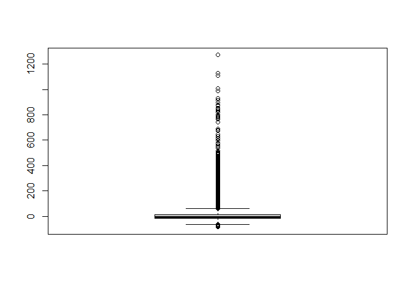

[output not shown]

[output cut: 1977 more lines]

```r
boxplot(flts$arr_delay)$out  #get the actual values of the outliers with this
```

```r
boxplot(flts$arr_delay, plot=FALSE)$out #(Optional) hide the plot using plot=FALSE
```

[output not shown]

[output cut: 1977 more lines]

```r
outliers <- boxplot(flts$arr_delay, plot=FALSE)$out #assign the outlier values into a vector
print(outliers) # Check the results
```

[output not shown]

[output cut: 1977 more lines]

```r
flts[which(flts$arr_delay %in% outliers),] # First you need find in which rows the outliers are
```

```
## # A tibble: 27,880 x 19
##     year month   day dep_time sched_dep_time dep_delay arr_time sched_arr_time
##    <int> <int> <int>    <int>          <int>     <dbl>    <int>          <int>
##  1  2013     1     1      811            630       101     1047            830
##  2  2013     1     1      848           1835       853     1001           1950
##  3  2013     1     1      957            733       144     1056            853
##  4  2013     1     1     1114            900       134     1447           1222
##  5  2013     1     1     1120            944        96     1331           1213
##  6  2013     1     1     1255           1200        55     1451           1330
##  7  2013     1     1     1301           1150        71     1518           1345
##  8  2013     1     1     1337           1220        77     1649           1531
##  9  2013     1     1     1342           1320        22     1617           1504
## 10  2013     1     1     1400           1250        70     1645           1502
## # ... with 27,870 more rows, and 11 more variables: arr_delay <dbl>,
## #   carrier <chr>, flight <int>, tailnum <chr>, origin <chr>, dest <chr>,
## #   air_time <dbl>, distance <dbl>, hour <dbl>, minute <dbl>, time_hour <dttm>
```

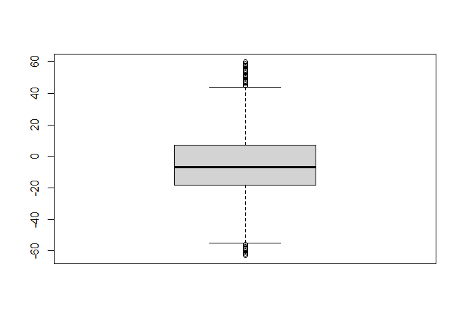

```r
fltsout <- flts[-which(flts$arr_delay %in% outliers),]  #remove the rows containing the outliers
boxplot(fltsout$arr_delay)  #check the boxplot, Now without outliers.
```

str(fltsout) #look at the data without outliers summary(fltsout) #look at the data without outliers

## [ ] Provide a distributional summary of the relevant variable in nycflights13::flights.

Distribution of Arr_Delays – using Density Plot from Top 50 Master List

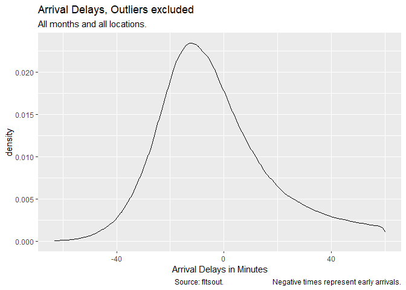

```r
g <- ggplot(fltsout, aes(arr_delay))
g + geom_density(aes(), alpha = 0.8) +
  labs(title = "Arrival Delays, Outliers excluded",
       subtitle = "All months and all locations.",
       caption = "Source: fltsout.                           Negative times represent early arrivals.",
       x = "Arrival Delays in Minutes"
     )
```

```r
ggsave("7TaskPlot1.png", width = 15, units = "in")
```

## [ ] Build bivariate summaries of the relevant variables.

Side-by-Side Box Plots of Each Month’s Arrival Delays

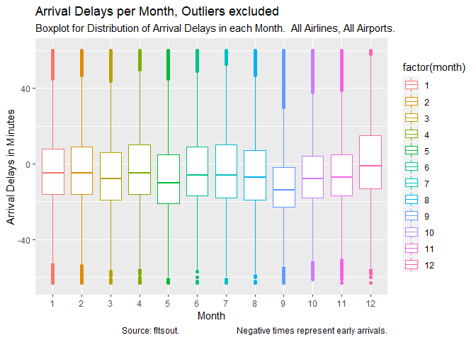

```r
ggplot(fltsout, aes(factor(month), arr_delay)) +    #add color, and side-by-side of auto&manual
  geom_boxplot(aes(color = factor(month))) +
  labs(title = "Arrival Delays per Month, Outliers excluded",
     subtitle = "Boxplot for Distribution of Arrival Delays in each Month.  All Airlines, All Airports.",
     caption = "Source: fltsout.                           Negative times represent early arrivals.",
     y = "Arrival Delays in Minutes",
     x = "Month"
     )
```

```r
ggsave("7TaskPlot2.png", width = 15, units = "in")
```

## [ ] document the iterative script that built to your insightful relationship.

See the notes and comments for each code line and code section.

## [ ] Review the “What do people do with new data” link above and write one quote that resonated with you in your .R file.

Quotable Quote from “What People Do With New Data”

#### *“If it is medical/social data I usually look for personally identifiable information, remove PII and burn it with fire — Peter Skomoroch”*

## [ ] In your .R script include also your data visualization development with 1-2 commented paragraphs summarizing your 2 finalized graphics and the choices you made in the data presentation.

### Data Manipulation

Data was brought in from flights datra frame.  
Str and ?Flights was used to understand the dataframe structure and variable definitions. From previous boxplots, I knew there were many, many outliers. The outliers were removed using code found on the rpubs.com website.  
Str and summary of the new fltsout dataframe was performed to see the new layout.

### Data Visualization

I decided that an interesting connection would be the relation between Month and Arrival_Delays. That is, is there a trend of better or worse arrival performance across the months of a year. Could there be logical (weather or human factors) explanations for these monthly changes in arrival performance?  
**A Dentisty Plot** was chosen from Top 50 Master List to show how the overall success rate for Arrivals.  
It shows that the average arrival time is actually ahead of schedule. And that there is a strong right tail (lateward). This is indicative of a safety-conscious and weather-dependent operation which can and should be delayed often.  
**Side-by-Side Boxplots** were used to show the biavriate relation between months of the year and arrival times. A separate boxplot for each month, side-by-side, with a common vertical (arrival lateness) scale. This plot is helpful in identifying which months have the most/least delays, and logical reasons can be inferred. Such as, Spring Break travel in April, Holiday Travel in December, Summer vacation travel, Less travel when school starts in September.

## [ ] Save your .png images of each your final graphics and push all your work (including your .R file) to your repository.

Used this code above: ggsave(“7TaskPlot1.png”, width = 15, units = “in”) #saves to the project folder, overwrites without asking

#### Scratch Use a Correlation matrix Select only numeric columns. From https://statisticsglobe.com/select-only-numeric-columns-from-data-frame-in-r

```r
num_cols <- unlist(lapply(flts, is.numeric))         # Identify numeric columns
num_cols
```

```
##           year          month            day       dep_time sched_dep_time
##           TRUE           TRUE           TRUE           TRUE           TRUE
##      dep_delay       arr_time sched_arr_time      arr_delay        carrier
##           TRUE           TRUE           TRUE           TRUE          FALSE
##         flight        tailnum         origin           dest       air_time
##           TRUE          FALSE          FALSE          FALSE           TRUE
##       distance           hour         minute      time_hour
##           TRUE           TRUE           TRUE          FALSE
```

```r
data_num <- flts[ , num_cols]                        # Subset numeric columns of data
data_num
```

```
## # A tibble: 336,776 x 14
##     year month   day dep_time sched_dep_time dep_delay arr_time sched_arr_time
##    <int> <int> <int>    <int>          <int>     <dbl>    <int>          <int>
##  1  2013     1     1      517            515         2      830            819
##  2  2013     1     1      533            529         4      850            830
##  3  2013     1     1      542            540         2      923            850
##  4  2013     1     1      544            545        -1     1004           1022
##  5  2013     1     1      554            600        -6      812            837
##  6  2013     1     1      554            558        -4      740            728
##  7  2013     1     1      555            600        -5      913            854
##  8  2013     1     1      557            600        -3      709            723
##  9  2013     1     1      557            600        -3      838            846
## 10  2013     1     1      558            600        -2      753            745
## # ... with 336,766 more rows, and 6 more variables: arr_delay <dbl>,
## #   flight <int>, air_time <dbl>, distance <dbl>, hour <dbl>, minute <dbl>
```

```r
str(data_num)
```

```
## tibble [336,776 x 14] (S3: tbl_df/tbl/data.frame)
##  $ year          : int [1:336776] 2013 2013 2013 2013 2013 2013 2013 2013 2013 2013 ...
##  $ month         : int [1:336776] 1 1 1 1 1 1 1 1 1 1 ...
##  $ day           : int [1:336776] 1 1 1 1 1 1 1 1 1 1 ...
##  $ dep_time      : int [1:336776] 517 533 542 544 554 554 555 557 557 558 ...
##  $ sched_dep_time: int [1:336776] 515 529 540 545 600 558 600 600 600 600 ...
##  $ dep_delay     : num [1:336776] 2 4 2 -1 -6 -4 -5 -3 -3 -2 ...
##  $ arr_time      : int [1:336776] 830 850 923 1004 812 740 913 709 838 753 ...
##  $ sched_arr_time: int [1:336776] 819 830 850 1022 837 728 854 723 846 745 ...
##  $ arr_delay     : num [1:336776] 11 20 33 -18 -25 12 19 -14 -8 8 ...
##  $ flight        : int [1:336776] 1545 1714 1141 725 461 1696 507 5708 79 301 ...
##  $ air_time      : num [1:336776] 227 227 160 183 116 150 158 53 140 138 ...
##  $ distance      : num [1:336776] 1400 1416 1089 1576 762 ...
##  $ hour          : num [1:336776] 5 5 5 5 6 5 6 6 6 6 ...
##  $ minute        : num [1:336776] 15 29 40 45 0 58 0 0 0 0 ...
```

Correlogram Plot of numeric columns 1-14 (not sure why it throws out some variables)

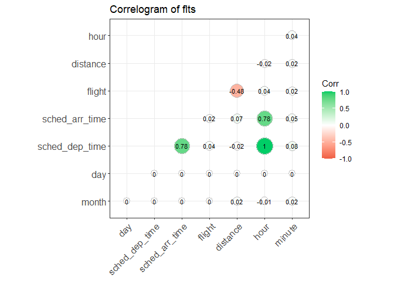

```r
ggcorrplot(cor(data_num[,1:14]),   #Correlogram from Top50 Master List
           type = "lower",
           lab = TRUE,
           lab_size = 3,
           method = "circle",
           colors = c("tomato2", "white", "springgreen3"),
           title = "Correlogram of flts",
           ggtheme = theme_bw)
```